# Troye Spotify Report

Author

Pradyumn

## Let’s talk about Loreen!

Mother of Eurovision - won 2 times (only female artist to do so) with Euphoria in 2012 and Tattoo in 2023. She was also the first artist I saw live.

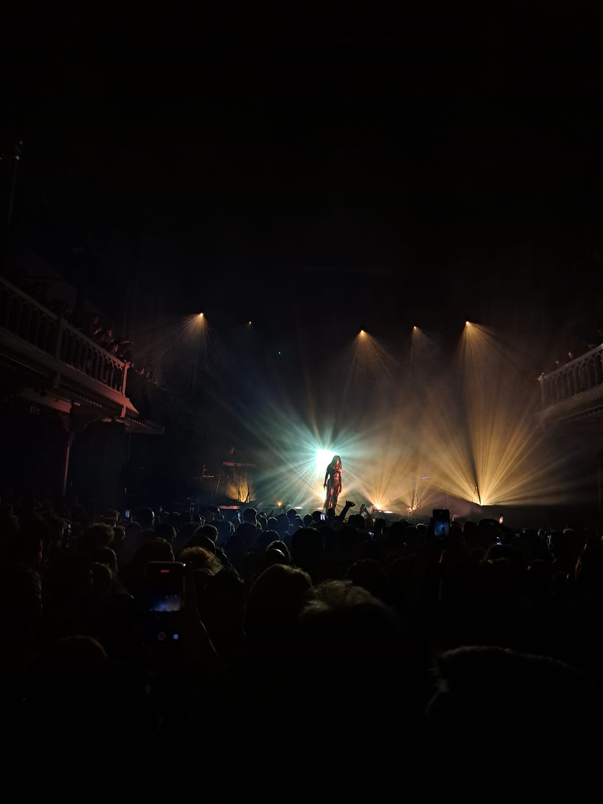

Also, shout out to Troye. I wanted to do his data analysis, but the data refused to work :(

### Albums and EPs:

**Albums:**

She has not done a lot of albums, mostly singles that releases on her platforms.

Ride (2017)

She also has had compilation albums like the remixes of Euphoria. Also, she did another EP in 2017 called Nude.

#### My Favorites:

**Song:**

[figure not shown]

FOREVER (2024) - I like the electronica vibe.

Here is her performing the song in Malmö:

[video not shown]

**My Favorite Lyrics:**

Violins playin’ and the angels cryin’  
When the stars align, then I’ll be there

No, I don’t care about them all  
’Cause all I want is to be loved  
And all I care about is you  
You’re stuck on me like a tattoo - Tattoo, 2023

I was obsessed with this song.

### Data Analysis

**Data Source**

I extracted the data using the spotify package, and stored it in the data folder.

**Import Data**

```r
#Packages needed for analysis
library(ggplot2)
library(dplyr)
library(knitr)

# importing the dataset
Loreen_Data <- read.csv("C:/Users/prady/OneDrive/Documents/P.Arora_SpotifyReport/Loreen.csv")
```

**The Data Frame**

```r
# Slice 5 random records in the dataframe
Loreen_Data |> dplyr::slice_sample(n=5) |> knitr :: kable (digit = 2)
```

| artist_name | track_name | track_number | album_name | album_release_year | album_release_date | valence | energy | danceability | loudness | tempo | speechiness | instrumentalness | liveness | key_name | mode_name | key_mode | duration_ms |
| --- | --- | --- | --- | --- | --- | --- | --- | --- | --- | --- | --- | --- | --- | --- | --- | --- | --- |
| Loreen | Fire Blue | 4 | Ride | 2017 | 11/24/2017 | 0.26 | 0.58 | 0.48 | -7.51 | 121.92 | 0.03 | 0 | 0.11 | G | minor | G minor | 259893 |
| Loreen | Heal (feat. Blanks) | 12 | Heal | 2012 | 10/19/2012 | 0.25 | 0.50 | 0.36 | -9.72 | 168.09 | 0.04 | 0 | 0.11 | C | major | C major | 279346 |
| Loreen | Heal (feat. Blanks) | 12 | Heal (2013 Edition) | 2013 | 5/31/2013 | 0.25 | 0.50 | 0.36 | -9.72 | 168.09 | 0.04 | 0 | 0.11 | C | major | C major | 279346 |
| Loreen | ’71 Charger | 1 | Ride | 2017 | 11/24/2017 | 0.40 | 0.54 | 0.36 | -6.69 | 177.93 | 0.04 | 0 | 0.16 | F | minor | F minor | 252360 |
| Loreen | Euphoria - Acoustic | 13 | Heal (2013 Edition) | 2013 | 5/31/2013 | 0.18 | 0.65 | 0.41 | -10.01 | 120.00 | 0.06 | 0 | 0.05 | G | major | G major | 250693 |

**Simplifying Data**

```r
# Remove the tracks with same names
Loreen_Data <- Loreen_Data |> distinct(track_name, .keep_all = TRUE)
# Change the data type of album_name from numeric into character
Loreen_Data$album_name <- as.character(Loreen_Data$album_name)
```

#### Album Analysis

Here are box plots comparing Loreen’s albums in terms of valance and energy.

Ps - The data does not include her singles that came after 2023.

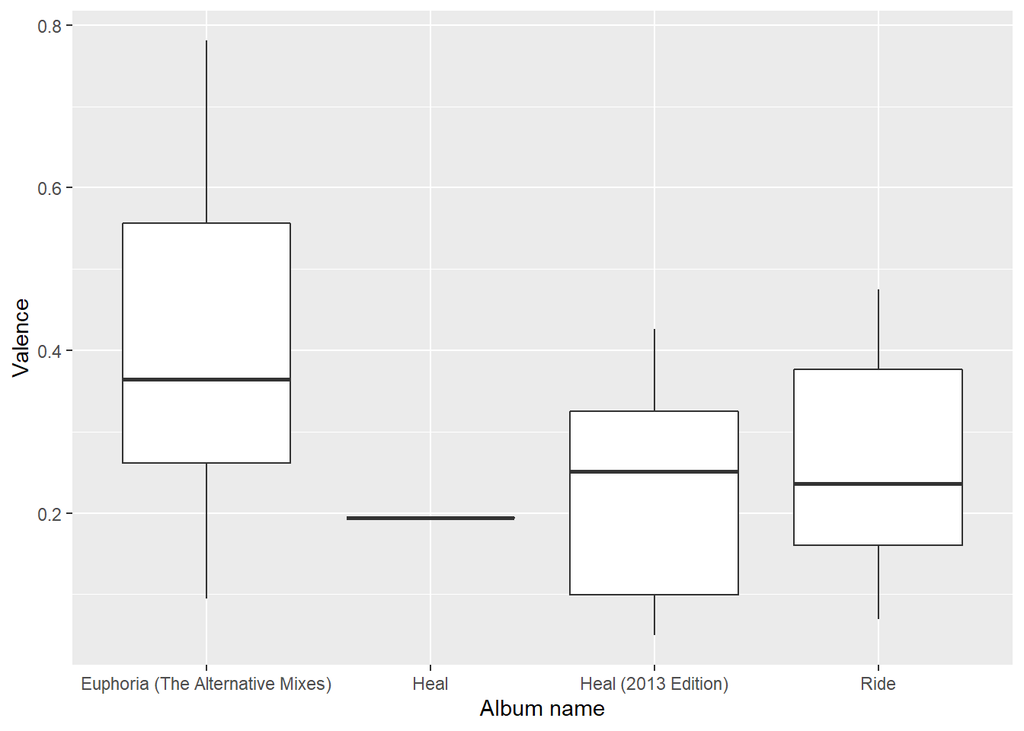

```r
# Change album_name from character to factor before plotting
Loreen_Data$album_name <- as.factor(Loreen_Data$album_name)
# plotting a boxplot
ggplot(Loreen_Data, aes(x=album_name, y = valence))+ geom_boxplot()+ labs(x="Album name", y = "Valence")
```

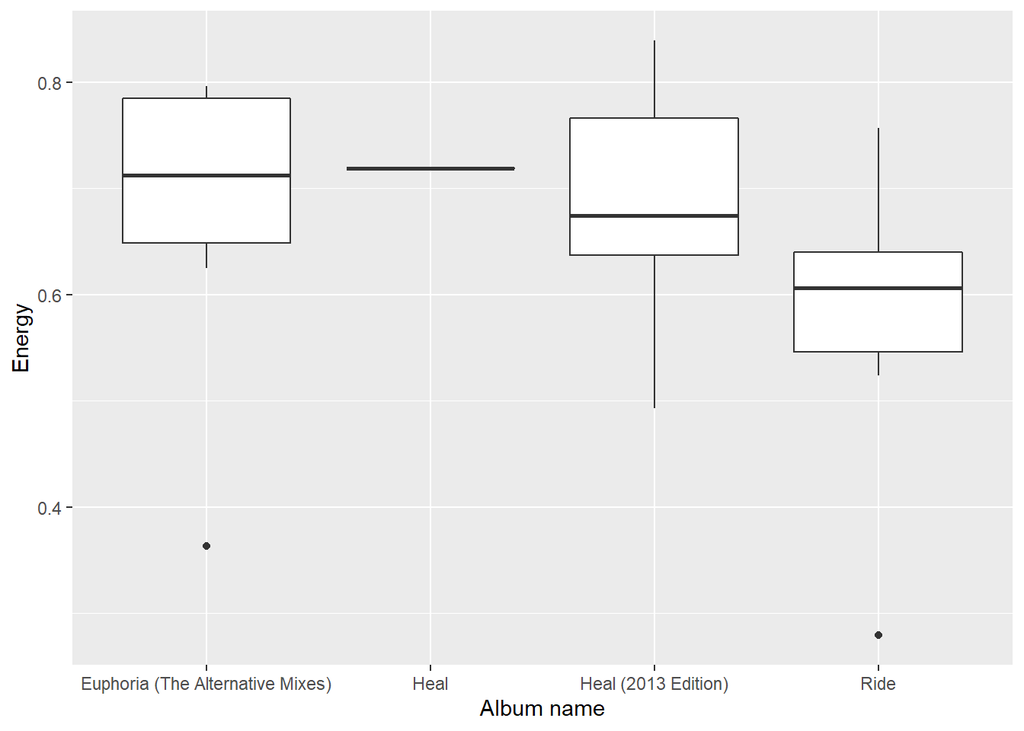

```r
#plotting another boxplot for energy
ggplot(Loreen_Data, aes(x=album_name, y=energy))+ geom_boxplot()+
  labs(x="Album name", y="Energy")
```

Now, I was interested in knowing whether her songs can be considered danceable and energetic.

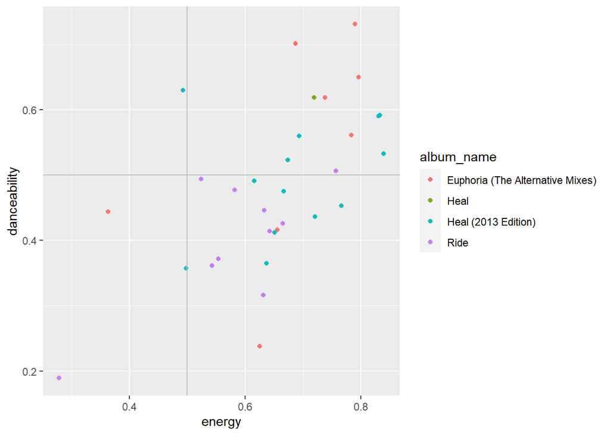

```r
# Deciphering a relationship between Loreen's songs energy and danceability
ggplot(Loreen_Data, aes(x = energy, y = danceability, color = album_name)) +
  geom_point() +
  geom_hline(yintercept = 0.5, color = "grey") +
  geom_vline(xintercept = 0.5, color = "grey")
```

#### The Most Positive Songs

Loreen sings a lot about love and heartbreak, so I wanted to see what are her most positive songs (according to the valance) from the data available:

```r
Loreen_Data |> slice_max(valence, n=3) |> dplyr::select(track_name, album_name, album_release_year, valence) |> knitr::kable(digits = 2)
```

| track_name | album_name | album_release_year | valence |
| --- | --- | --- | --- |
| Euphoria (WAWA Remix) | Euphoria (The Alternative Mixes) | 2023 | 0.78 |
| Euphoria (Tiger & Wolf Remix) | Euphoria (The Alternative Mixes) | 2023 | 0.56 |
| Euphoria (Alex Moreno Remix) | Euphoria (The Alternative Mixes) | 2023 | 0.56 |

And now let’s look at her most danceable songs:

```r
Loreen_Data |> slice_max(danceability, n=3) |> dplyr::select(track_name, album_name, album_release_year, danceability) |> knitr::kable(digits = 2)
```

| track_name | album_name | album_release_year | danceability |
| --- | --- | --- | --- |
| Euphoria (Carli Remix) | Euphoria (The Alternative Mixes) | 2023 | 0.73 |
| Euphoria (Tiger & Wolf Remix) | Euphoria (The Alternative Mixes) | 2023 | 0.70 |
| Euphoria (WAWA Remix) | Euphoria (The Alternative Mixes) | 2023 | 0.65 |

Clearly, Euphoria is still a people pleaser go to Europop song. Let’s listen to it:

[video not shown]